# PMLP_Jawbone

Mark Rayfield

9/15/2020

## Summary

The data analysis conducted below results in a model used to predict personal activity monitoring using a suite of health monitoring devices. A large traning data set with 19,622 observations is made available under the Creative Commons license (CC BY-SA). The data used in this project relates to identifying weight lifting technique as part of human acrivity recognitio. The training data is split into a training and cross validations sets and the rsulting selected model used to predict technique (**classe**) for a limted 20 observation test data set with no **classe** provided. Overall the random forest model selected has an out of sample error rate of 0.5% for factor "classe".

The HTML version from `knitr` of this Rmarkdown file can be viewed by reveiwers in the "gh-pages"" branch of this github repository by *copy pasting* the address below in a web browser (http://Mark66Rayfield.github.io/practicalmachinelearning).

## 1. Data Provided

The training data for this project are available here: https://d396qusza40orc.cloudfront.net/predmachlearn/pml-training.csv

The test data for the final are available here: https://d396qusza40orc.cloudfront.net/predmachlearn/pml-testing.csv

The data for this project come from this source [HAR](http://groupware.les.inf.puc-rio.br/har) and credit is given to the original authors named below: .

VELLOSO, E.; BULLING, A.; GELLERSEN, H.; UGULINO, W.; FUKS, H. Qualitative Activity Recognition of Weight Lifting Exercises. Proceedings of 4th International Conference in Cooperation with SIGCHI (Augmented Human ’13) . Stuttgart, Germany: ACM SIGCHI, 2013.

## 1.1 Loading and Cleaning Data

The following libraries and data are loaded for this analysis

```r
library(caret)
```

```r
library(knitr)
library(rpart)
library(rpart.plot)
library(randomForest)
library(corrplot)
library(parallel)
library(doParallel)
# load with NA and blanks as NA's
testing <- read.csv("https://d396qusza40orc.cloudfront.net/predmachlearn/pml-testing.csv", na.strings=c("NA",""))
training <- read.csv("https://d396qusza40orc.cloudfront.net/predmachlearn/pml-training.csv", na.strings=c("NA",""))
dim(training)
```

```
## [1] 19622   160
```

```r
xtabs(~user_name+classe, data = training)
```

```
##           classe
## user_name     A    B    C    D    E
##   adelmo   1165  776  750  515  686
##   carlitos  834  690  493  486  609
##   charles   899  745  539  642  711
##   eurico    865  592  489  582  542
##   jeremy   1177  489  652  522  562
##   pedro     640  505  499  469  497
```

```r
# clean and tidy data
# based on training data remove columns with NA values
NAs <- apply(training,2,function(x) {sum(is.na(x))}) # sum NA's by column
train.clean <- training[,which(NAs == 0)]
test.clean <- testing[,which(NAs == 0)]
# Removing admin variables, keep user_id [ ,2] for traceback purposes
removeIndex <- as.integer(c(1,3,4,5,6,7))
train.clean <- train.clean[,-removeIndex]
dim(train.clean)
```

```
## [1] 19622    54
```

```r
# test data has no "classe"" variable remove dummy last column "problem_id" repeats "X"
test.clean <- test.clean[,-removeIndex]
test.clean <- test.clean[ ,-54]
dim(test.clean)
```

```
## [1] 20 53
```

The tidy sets have 54 columns, timestamp and window variables with limited variance have been removed as predictor variables.

## 1.2 EDA

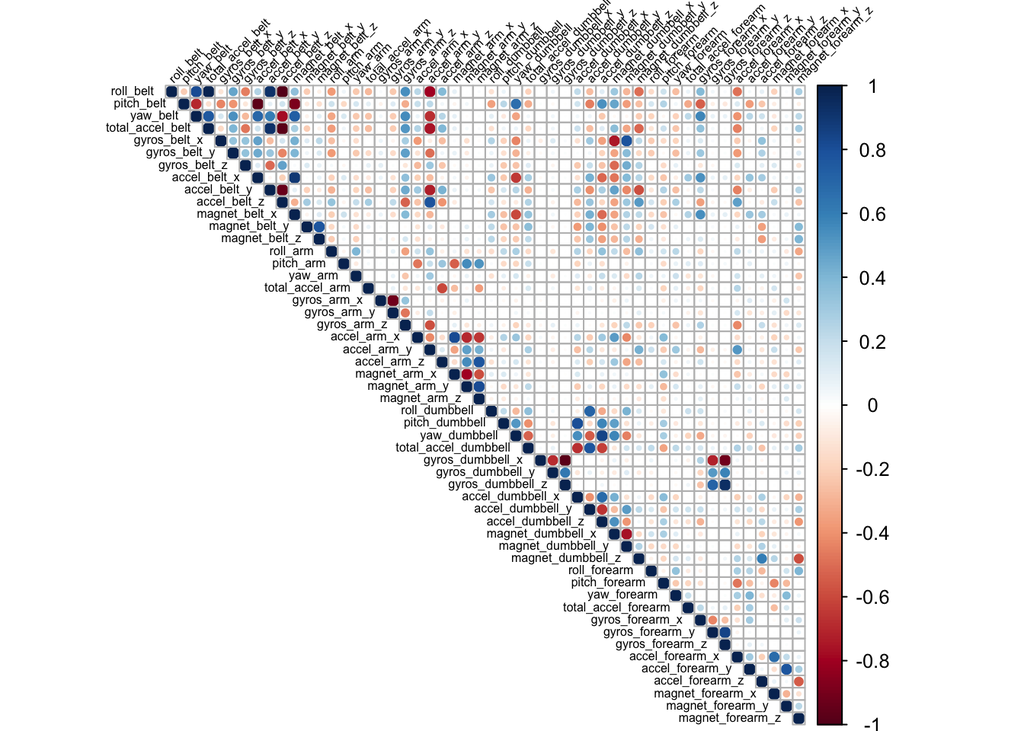

```r
Matrix<-cor(train.clean[ , -c(1,54)]) # remove factor variables
corrplot(Matrix, type="upper", tl.col="black", tl.srt=45, tl.cex = 0.5)
```

A significant number of highly correlated predictors are apparent, **colinearity** needs to be addressed in the selected classification model selection.

## 1.3 Building data sets for training and cross validation.

The training data set has 19,622 observations, 70% of the data is allocated to the training model and 30% for Cross Validation purposes.

```r
set.seed(12345)
trainIndex <- createDataPartition(y = train.clean$classe, p=0.7,list=FALSE)
trainSet <- train.clean[trainIndex,]
crossValidationSet <- train.clean[-trainIndex,]
```

## 2.0 Model Selection

*Classe* is a multi level classification problem which the [caret documentation](https://topepo.github.io/caret/models-clustered-by-tag-similarity.html) indicates is generally solved with *random forrest* but other simpler and less computationally expensive options such as *decision trees* and *linear discriminant analysis (lda)* are possible alternatives. The latter as a linear approach suffers with correlated variables of which there are a number in this data set and has not been pursued. A *stacked* model approach was a possiblity if desired accuracy was not attained but was not necessary for this projcet.

As a strategy a simpler decision tree and a random forrest appraoch will be pursued to understand differences in accuracy with this being the criteria for recommended model. The decision tree through `rpart` and the random forest for which parallel precessing is invoked under the caret package.

## 2.1 Decision Tree Training & Cross Validation

```r
set.seed(1)
fit <- rpart(classe ~ ., data=trainSet, method="class")
predict_rpart <- predict(fit, newdata=crossValidationSet, type = "class")
confusionMatrix(predict_rpart, crossValidationSet$classe)$table
```

```
##           Reference
## Prediction    A    B    C    D    E
##          A 1532  176   28   48   41
##          B   54  585   57   64   76
##          C   35  154  819  134  126
##          D   25   76   58  631   56
##          E   28  148   64   87  783
```

```r
round(confusionMatrix(predict_rpart, crossValidationSet$classe)$overall[1:4],3)
```

```
##      Accuracy         Kappa AccuracyLower AccuracyUpper
##         0.739         0.669         0.728         0.750
```

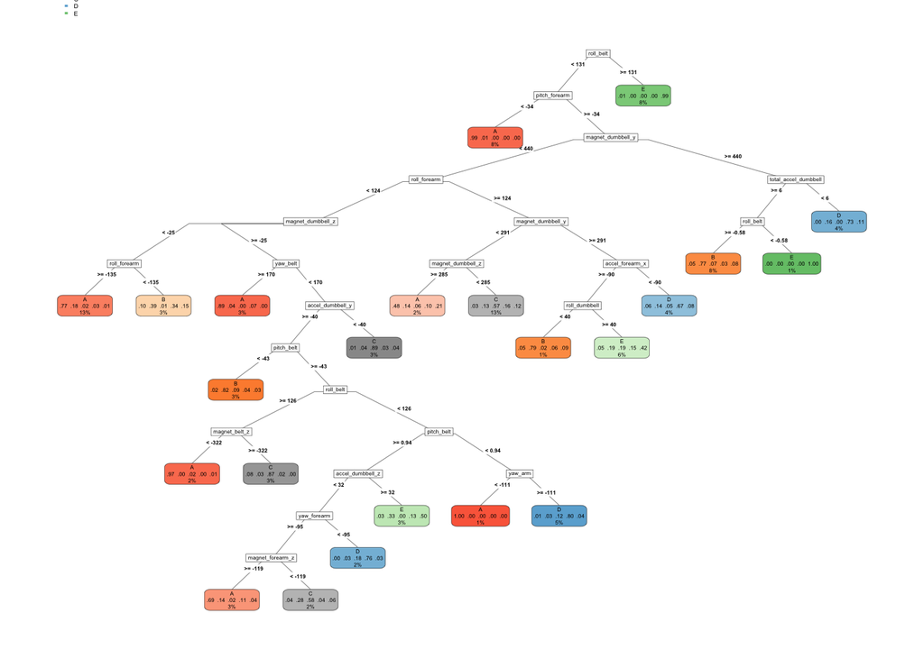

```r
# illustrate decision tree
rpart.plot(fit, type = 5,extra = "auto", fallen.leaves = FALSE)
```

`rpart::rpart` recursive partitioning and regression tree is a simple and quick model which fits the `trainSet` in less than 30 seconds. When used in prediction on `crossValidationSet` results in 4350 of 5885 observations being classified correctly for an **accuracy** of 73.9% 95% CI (0.728 to 0.750) and its complement out of sample (OOS) error rate of 0.261.

## 2.2 Random Forest Training & Cross Validation

```r
cluster <- makeCluster(detectCores() - 1) # convention to leave 1 core for OS
registerDoParallel(cluster)
# default is bootstrap resampling, using 5 fold K
fitControl <- trainControl(method = "cv", number = 5, allowParallel = TRUE)
# 409 sec on 4GB RAM 2014 iMac
system.time(fit_rf <- train(classe ~ ., method="rf",data=trainSet,trControl = fitControl))
```

```
##    user  system elapsed
##  44.601   1.623 333.713
```

```r
stopCluster(cluster) # end parallel working
registerDoSEQ()
```

```r
predict_rf <- predict(fit_rf, newdata=crossValidationSet)
confusionMatrix(predict_rf, crossValidationSet$classe)$table
```

```
##           Reference
## Prediction    A    B    C    D    E
##          A 1672    6    0    0    0
##          B    1 1130    5    0    0
##          C    1    3 1018    8    2
##          D    0    0    3  955    0
##          E    0    0    0    1 1080
```

```r
round(confusionMatrix(predict_rf, crossValidationSet$classe)$overall[1:4],3)
```

```
##      Accuracy         Kappa AccuracyLower AccuracyUpper
##         0.995         0.994         0.993         0.997
```

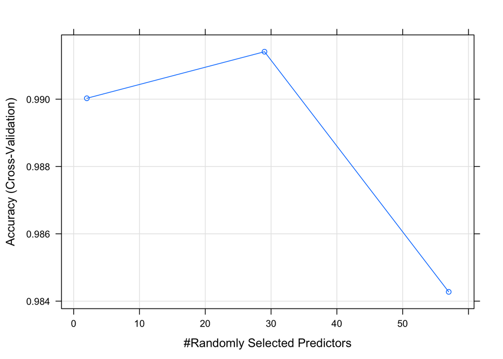

```r
x <- varImp(fit_rf, scale = FALSE)
par(mfrow = c(1,2))
plot(fit_rf, log="y")
```

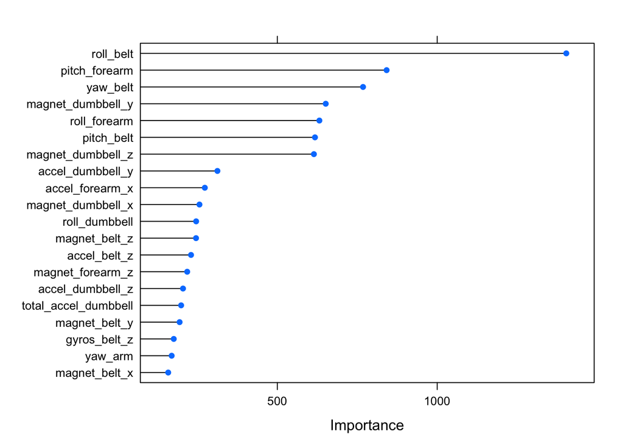

```r
plot(x, top = 20)
```

## 3.0 Prediction using provided "Testing" data

Using the preferred random forest model with `mtry=29` and the 20 row `test.clean` data set which has no **classe** variable provided. The 20 answers are written to the screen and a text file `test.txt` stored in the Github repository.

```r
answers <-predict(fit_rf, newdata = test.clean)
answers
```

```
##  [1] B A B A A E D B A A B C B A E E A B B B
## Levels: A B C D E
```

```r
write.table(answers,file="test.txt",col.names = NA,row.names = TRUE)
```